# Who Votes?

An introduction to logistic regression, using survey data on voter turnout

November 3, 2026

## Assumed knowledge

- Familiarity with linear regression modeling
- Familiarity with programming in R

Activity A · 2 min

### Two quick polls

1. In the **2022 midterm**, what share of eligible Americans voted?  
   **(a)** 30% **(b)** 45% **(c)** 60% **(d)** 75%
2. Which best predicts whether someone votes?  
   age · education · income · strength of party ID

## Today’s question

> **Who is likely to vote in today’s midterm election?**

The response is **binary**: votes (1) or doesn’t (0).

Today we’ll learn:

- **when** to use logistic regression
- how to **fit** a logistic regression
- how to **interpret** the regression coefficients
- how to **evaluate** the model
- how to make **predictions**

## The data: General Social Survey

- Nationally representative survey of US adults (NORC), run every 1-2 years since 1972
- Focused on tracking American public attitudes, behaviors, and attributes
- Free in R via the [`gssr`](https://kjhealy.github.io/gssr/) package

```r
library(gssr)                               # from kjhealy.r-universe.dev
data(gss_all)                               # every GSS survey, 1972–2024
dim(gss_all)
```

## Filter the data: General Social Survey 2024

Question: Did you **vote in the 2020 presidential election**?

```r
vote <- gss_all %>%
  filter(year == 2024, vote20 %in% 1:2) %>% # 1 = voted, 2 = did not
  mutate(voted = as.integer(vote20 == 1))
```

2,441

eligible respondents, complete answers

78%

say they voted in 2020

66%

actually voted (official count)

## Variables we’ll use

`dim(vote)`: **2,441 rows × 8 columns**

| Variable | Meaning | Values |
| --- | --- | --- |
| `voted` | Voted in 2020? (**response**) | 0 / 1 |
| `age`, `age10` | Age in years; age in decades | 18–89 |
| `educ` | Years of schooling | 0–20 |
| `degree` | Highest degree | 5 levels |
| `inc10k` | Family income, in $10,000s | 0.04–17 |
| `married` | Currently married? | 0 / 1 |
| `pstrength` | Strength of party ID, *either* party | 0 = independent … 3 = strong |

## A glimpse of the data

```r
glimpse(vote)
```

```
Rows: 2,441
Columns: 8
$ voted     <int> 1, 1, 1, 1, 0, 1, 1, 1, 1, 1, 1, 1, 1, 0, 1, 1, 1, 1…
$ age       <dbl> 33, 64, 69, 70, 48, 60, 23, 68, 37, 63, 31, 64, 63, …
$ age10     <dbl> 3.3, 6.4, 6.9, 7.0, 4.8, 6.0, 2.3, 6.8, 3.7, 6.3, 3.…
$ educ      <dbl> 16, 16, 14, 13, 13, 14, 18, 5, 12, 12, 19, 16, 11, 8…
$ degree    <fct> Bachelor's, Graduate, Associate, High school, High s…
$ inc10k    <dbl> 6.756000, 3.800250, 6.756000, 3.800250, 13.902437, 1…
$ married   <int> 0, 0, 1, 0, 1, 1, 0, 0, 0, 0, 1, 1, 1, 0, 0, 1, 0, 1…
$ pstrength <dbl> 2, 3, 3, 0, 3, 2, 3, 1, 0, 0, 3, 1, 3, 2, 0, 3, 2, 3…
```

```r
vote %>% count(voted)
```

```
# A tibble: 2 × 2
  voted     n
  <int> <int>
1     0   533
2     1  1908
```

## Who says they voted?

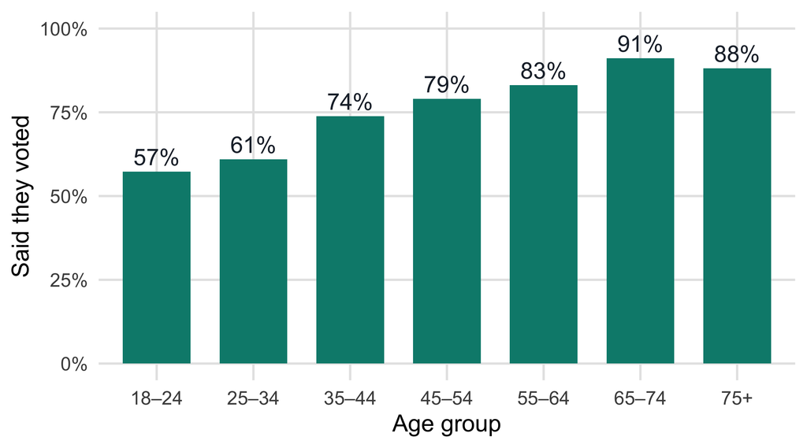

## What happens if we fit a linear regression?

```r
lpm <- lm(voted ~ age, data = vote)
```

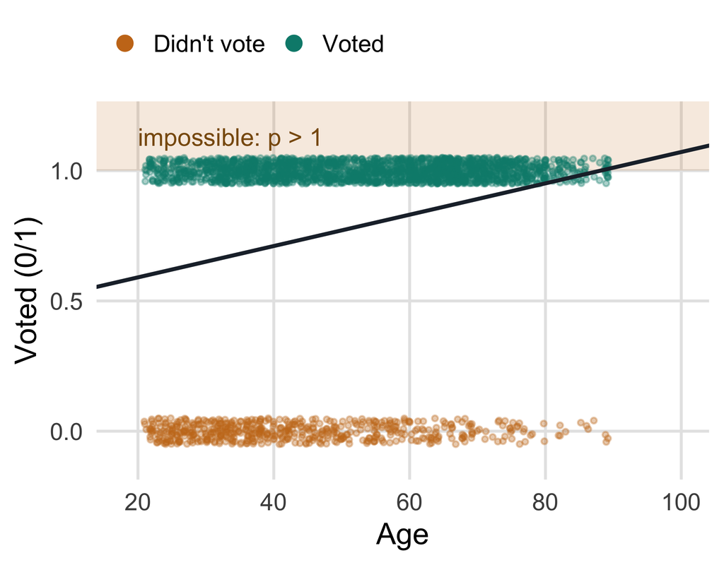

1. **Impossible predictions**: when age > 88, fitted values exceed 1
2. **Residuals not Normal**: $Y$ is 0 or 1
3. **Variance changes** with $p = P(\text{vote})$
4. **Wrong shape**: should flatten near $p=0$ and $p=1$

## From probability to log-odds

We need to transform $p$ to a variable that can take **any** value, like a linear model can.

Probability

$p$

$[0,\ 1]$

→divide by 1 − p

Odds

$\dfrac{p}{1-p}$

$[0,\ \infty)$

→take the log

Log-odds (logit)

$\log\!\left(\dfrac{p}{1-p}\right)$

$(-\infty,\ \infty)$

A linear predictor also lives on $(-\infty, \infty)$, so we can set them equal:

$$\text{logit}(p) = \log\!\left(\frac{p}{1-p}\right) = \beta_0 + \beta_1 x$$

## Examples: $p$, odds and log-odds

| Turnout | Probability | Odds | Log-odds |
| --- | --- | --- | --- |
| 2022 midterm (official) | 0.46 | 0.85 | -0.16 |
| 2020 presidential (official) | 0.66 | 1.94 | 0.66 |
| 2020, as reported in GSS | 0.78 | 3.58 | 1.28 |
| Coin flip | 0.50 | 1.00 | 0.00 |

- $p = 0.5 \;\Leftrightarrow\;$ odds $= 1 \;\Leftrightarrow\;$ log-odds $= 0$
- $p < 0.5 \;\Leftrightarrow\;$ negative log-odds
- $p > 0.5 \;\Leftrightarrow\;$ positive log-odds

Activity B · 2 min, pairs

### Odds speed round

1. Odds of voting are **3 to 1**. Probability?
2. Probability is **0.4**. Odds? Log-odds?
3. Log-odds are **−1**. Probability?

(1) 3/4 = 0.75 · (2) odds 0.67, log-odds −0.41 · (3) e<sup>−1</sup>/(1 + e<sup>−1</sup>) ≈ 0.27

## The logistic regression model

$$\log\!\left(\frac{p_i}{1-p_i}\right) = \beta_0 + \beta_1 x_i
\quad\Longleftrightarrow\quad
p_i = \frac{e^{\beta_0 + \beta_1 x_i}}{1 + e^{\beta_0 + \beta_1 x_i}}$$

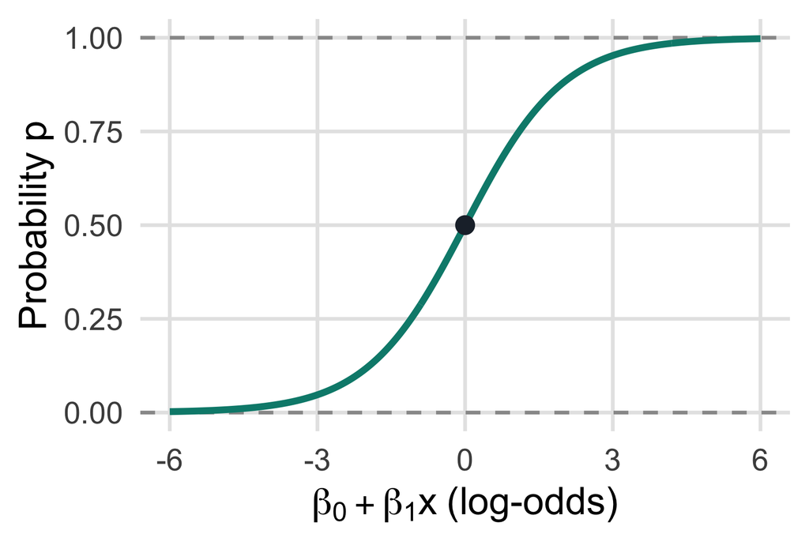

- The **logit link** connects $p$ to the linear part
- A **generalized linear model** (GLM) with Bernoulli $Y$
- In R:

```r
glm(y ~ x, family = binomial)
```

## Assumptions of logistic regression

1. **Binary response**: $Y_i \sim \text{Bernoulli}(p_i)$
2. **Independent** observations
3. **Linear on the log-odds scale**
4. No severe **multicollinearity**
5. Enough events per predictor (≈ 10); no **perfect separation**

**Not** needed: Normal residuals, constant variance

## How is it fit? No closed form

- Linear regression has a formula: $\hat{\beta} = (X^{\top}X)^{-1}X^{\top}y$
- Logistic regression **maximizes the log-likelihood**:

$$\ell(\beta) = \sum_{i=1}^{n} \Big[ y_i \log p_i + (1 - y_i) \log(1 - p_i) \Big]$$

- The equations are **non-linear in $\beta$**: no algebraic solution
- R searches **iteratively** (algorithm: Iteratively re-weighted least squares (IRLS) / Newton–Raphson)

## What R does: IRLS algorithm, step by step

```r
glm_age <- glm(voted ~ age, family = binomial, data = vote)
```

| Step | β₀ | β₁ (age) | Log-likelihood |
| --- | --- | --- | --- |
| 1 | -0.1194 | 0.0241 | -1221.427 |
| 2 | -0.5041 | 0.0359 | -1203.929 |
| 3 | -0.5797 | 0.0380 | -1203.573 |
| 4 | -0.5817 | 0.0381 | -1203.572 |
| 5 | -0.5817 | 0.0381 | -1203.572 |

Start at $\beta = (0, 0)$ → converged in ~4 steps, matching `glm()`.

Activity C · 4 min, pairs **Be the algorithm**: drag the sliders to maximize the log-likelihood.

Intercept β₀

Slope β₁ (per year of age)

Log-likelihood: Your best:

## Simple logistic regression: age

$$\log\!\left(\frac{p_i}{1-p_i}\right) = \beta_0 + \beta_1\,\text{age}_i$$

```r
m_age <- glm(voted ~ age, family = binomial, data = vote)
tidy(m_age) %>%
  mutate(p.value = format.pval(p.value, eps = 0.001, digits = 2)) %>%
  kable(digits = 3)
```

| term | estimate | std.error | statistic | p.value |
| --- | --- | --- | --- | --- |
| (Intercept) | -0.582 | 0.156 | -3.719 | <0.001 |
| age | 0.038 | 0.003 | 11.823 | <0.001 |

Fitted: $\log\!\left(\dfrac{\hat{p}}{1-\hat{p}}\right) = -0.58 + 0.038\,\text{age}$

## Interpreting coefficient estimates

$$\log\!\left(\frac{p}{1-p}\right) = \beta_0 + \beta_1 x$$

- What does $\beta_0$ represent?
- How about $\beta_1$?

## Interpreting coefficient estimates

| term | estimate | std.error | statistic | p.value |
| --- | --- | --- | --- | --- |
| (Intercept) | -0.582 | 0.156 | -3.719 | <0.001 |
| age | 0.038 | 0.003 | 11.823 | <0.001 |

- At age = 0, the **log-odds** of voting are -0.582
- When we increase age by one year, the **log-odds** of voting increases by 0.038
- **Odds ratio:** $e^{0.038} = 1.039$ per year
- Per **decade**: $e^{10 \times 0.038} = 1.46$, so **46% higher odds**

## The fitted curve vs. the data

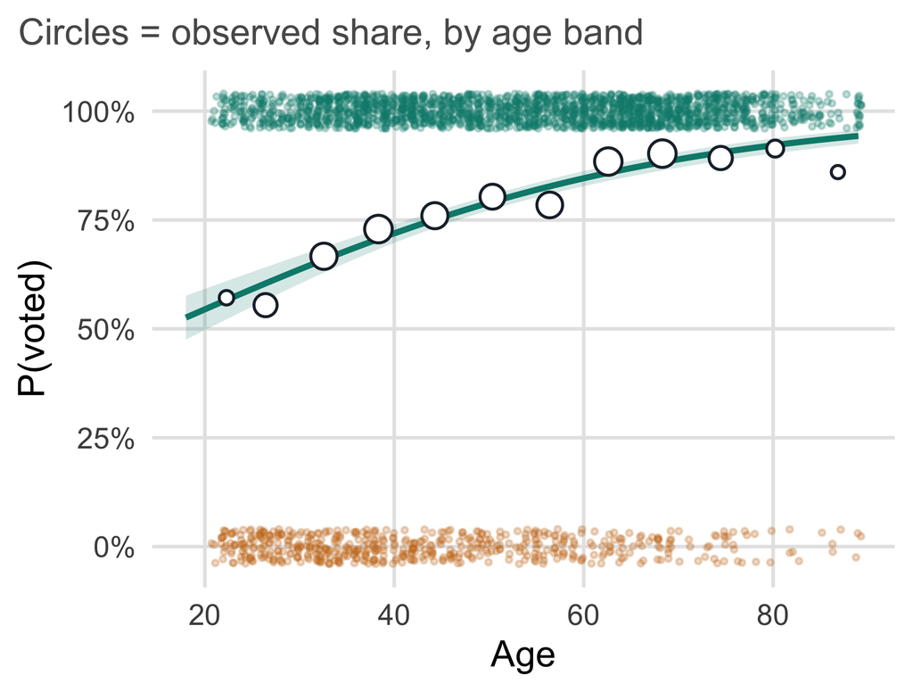

```r
tibble(age = c(20, 50, 80)) %>%
  mutate(p_hat = predict(m_age, .,
                 type = "response"))
```

```
# A tibble: 3 × 2
    age p_hat
  <dbl> <dbl>
1    20 0.545
2    50 0.789
3    80 0.922
```

[output not shown]

Activity D · 3 min, think–pair–share

### Being married

```r
m_mar <- glm(voted ~ married, family = binomial, data = vote)
```

| term | estimate | std.error | statistic | p.value |
| --- | --- | --- | --- | --- |
| (Intercept) | 1.046 | 0.061 | 17.079 | <0.001 |
| married | 0.584 | 0.103 | 5.652 | <0.001 |

1. Interpret the effect of marriage on probability of voting in 1-2 sentences.
2. Does marriage *make* people vote? What are some possible explanations for what is observed?

Married respondents tend to be older, more educated and better off financially. Let’s adjust for those…

## Multiple logistic regression

$$\log\!\left(\frac{p_i}{1-p_i}\right) = \beta_0 + \beta_1\,\text{age10}_i + \beta_2\,\text{educ}_i + \dots + \beta_5\,\text{married}_i$$

```r
m_full <- glm(voted ~ age10 + educ + inc10k + pstrength + married,
              family = binomial, data = vote)
```

| Predictor | Odds ratio | 95% CI | p-value |
| --- | --- | --- | --- |
| Age (per 10 years) | 1.42 | 1.33 – 1.53 | < 0.001 |
| Education (per year) | 1.22 | 1.16 – 1.27 | < 0.001 |
| Income (per $10k) | 1.17 | 1.12 – 1.22 | < 0.001 |
| Party ID strength (per step) | 2.03 | 1.84 – 2.26 | < 0.001 |
| Married | 0.81 | 0.63 – 1.05 | 0.110 |

## Reading the multiple model

- Each odds ratio: **holding the other predictors constant**
- **Married:** 1.79 alone → 0.81 adjusted, so mostly **confounding**
- **Party ID strength:** ×2.03 odds per step (either party)
- Strong partisan vs. independent: $e^{3\beta} \approx 8.41\times$ the odds

## Picturing “holding constant”

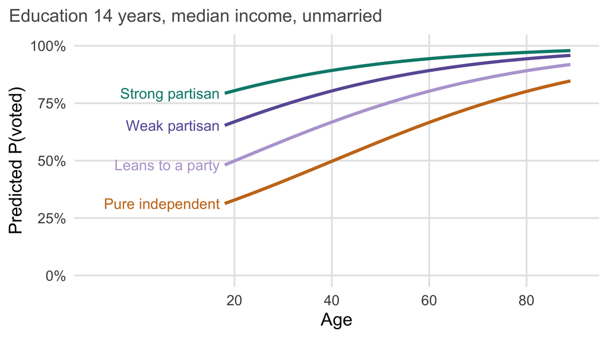

## Model evaluation and selection

| Model | Deviance | AIC |
| --- | --- | --- |
| Null | 2562.15 | 2564.15 |
| Age | 2407.14 | 2411.14 |
| Degree | 2355.64 | 2365.64 |
| Age + education | 2203.10 | 2209.10 |
| Full model | 1919.52 | 1931.52 |

- **Deviance** $= -2\ell$ (where $\ell =$ log likelihood; lower is better)
- **AIC** $= 2K -2\ell$ (i.e., penalizes parameters $K$)
- **Likelihood ratio test** $= 2(\ell_{\text{full}} - \ell_{\text{reduced}})$ (drop in deviance; larger is better)
  - Compare `full` vs. `age + education` models: deviance drops 284 on 3 df, p < 0.001

## Calibration

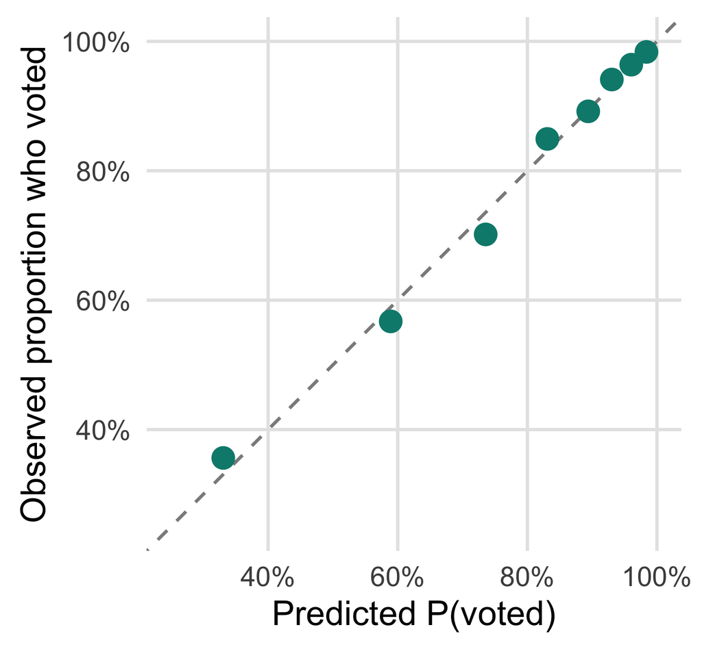

- **Calibration**: The agreement between a model’s predicted probabilities and the actual observed frequencies of an event
- Split people into 8 groups by predicted probability
- Compare observed vs. predicted share who voted
- On the dashed line → observed = predicted → perfect calibration

Cut-off: predict ‘vote’ if p̂ > 0.5

|  | Actual: no | Actual: vote |
| --- | --- | --- |
| Predicted: no | 204 | 114 |
| Predicted: vote | 329 | 1794 |

## Classification

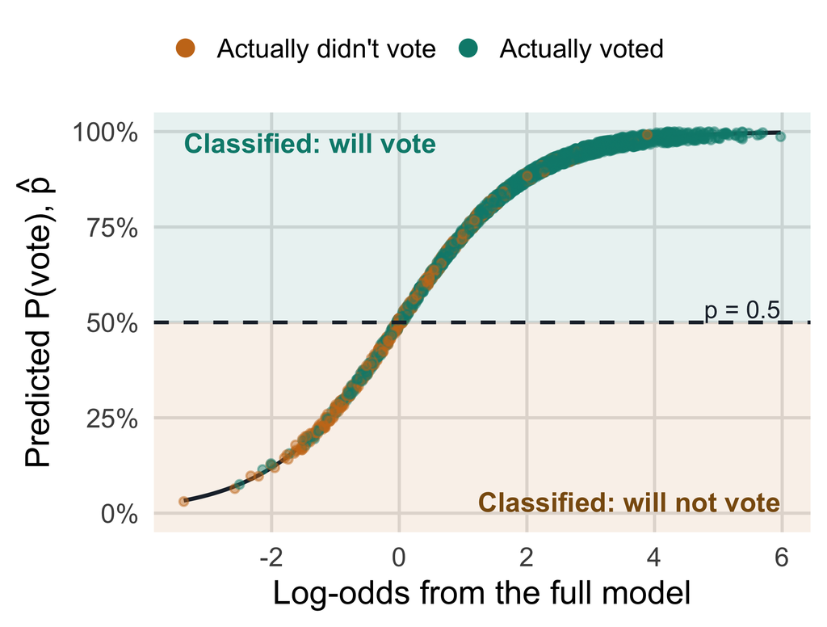

- **Binary classification**: Separate data into two distinct classes (i.e. will vote vs. will not vote)
- Each dot is one person, placed on the model curve
- **Rule:** predict “will vote” if $\hat{p} > 0.5$
- Amber dots above the line and teal dots below it are **misclassified**

## Classification: accuracy

Cut-off: predict ‘vote’ if p̂ > 0.5

|  | Actual: no | Actual: vote |
| --- | --- | --- |
| Predicted: no | 204 | 114 |
| Predicted: vote | 329 | 1794 |

**Accuracy** = share classified correctly

$$\begin{aligned}
\text{Accuracy} &= \frac{\text{correct predictions}}{\text{total}} \\[4pt]
&= \frac{204 + 1794}{2441} = 0.819
\end{aligned}$$

- Accuracy 82%, but “everyone votes” gets 78%
- The best threshold for classification depends on costs associated with false negatives vs. false positives

## Discrimination: ROC curve and AUC

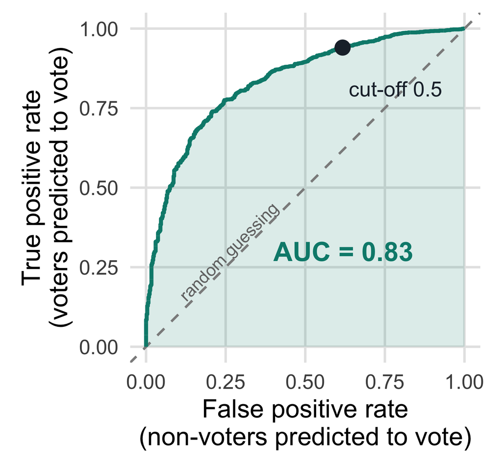

- **Discrimination**: how well does the model *rank* voters above non-voters?
- **ROC curve**: true vs. false positive rate for **every** cut-off
- **AUC** = area under the curve
  - $P(\hat{p}_{\text{voter}} > \hat{p}_{\text{non-voter}})$
  - 0.5 = random, 1 = perfect
- **AUC = 0.83**: a random voter outranks a random non-voter 83% of the time

## A fairer approach to model evaluation: Use new data

Apply the 2024 model to **2022** GSS respondents:

```r
vote22$p_hat <- predict(m_full, newdata = vote22, type = "response")
```

2,610

new respondents

78%

average prediction (79% said they voted)

0.81

AUC on new data (0.83 before)

## Review

- When to use logistic regression
  - **Binary response**
  - Linear on the **log-odds** scale; S-curve for $p$
- How to fit the model
  - $\text{logit}(p) = \beta_0 + \beta_1X_1 + \dots \beta_kX_k$
  - glm(Y ~ X, family = binomial, data = data)
  - No closed form solution → R uses IRLS algorithm

## Review - Continued

- Interpretation of coefficients
  - $\beta_0$ = **log odds** when $X$ = 0
  - $\beta_1$ = **change in log odds** associated with a 1 unit increase in $X_1$, holding all else constant
  - $e^{\beta}$ = **odds ratio**
- Model evaluation
  - Deviance, AIC, Likelihood ratio test
  - Calibration
  - Discrimination

## Independent practice

1. Fit your own model(s) and predict who will vote today!
2. What are the most important predictors in your model? Interpret the coefficients for a general audience.

## Data & sources

- **Survey data:** General Social Survey (NORC at the University of Chicago), 2022 and 2024; variable `vote20`. Via the [`gssr`](https://kjhealy.github.io/gssr/) R package.
- **Official turnout:** UF Election Lab, [1980–2022 General Election Turnout Rates (v1.1)](https://election.lab.ufl.edu/dataset/1980-2022-general-election-turnout-rates-v1-1): 66.0% (2020), 45.9% (2022).
- **Validated turnout:** [Cooperative Election Study](https://tischcollege.tufts.edu/research-faculty/research-centers/cooperative-election-study/data-downloads).
- Analysis is unweighted for simplicity.

Built with R 4.5.2 and Quarto. Press **S** for speaker notes.